# GNU make and Makefile for rerpoducibility

4/27/2021

## TOC

## Disclaimer

- This is not the solution to all [coding] problems
- It is merely another tool in your DataScience toolbox (albeit, a useful one!)

## Motivation: the problem

- Coding is rarely linear
- We often have to go back and change data, assumptions, transformations, filters, colors, font types
- Projects can get really big really fast… and re-running an entire Rmd file is not an option (well, kinda)
- We rarely work alone (new data, new approaches, new questions…)

## Motivation: an example

We’ll simulate everyone’s nightmare:

- You have built your “coding pipeline” and are ready to do something with it
- Then, you (or a colleague) finds an error in the raw data (crisis!!!)
- You fix the error, and now have to rerun the ENTIRE analysis. Chaos:
- *which script did what, again?*
- *What depended on what?*
- By the time you are done figuring this out, you’ve also gotten your hands on more data so… gotta re-run everything again

## [Self-]Motivation:

> The solution lies in the problem -> The problem lies in the solution

## Consider a case

```bash
data
    |_raw_data.csv
    |_clean_data.csv
scripts
    |_clean_data.R
    |_plot_data.R
results
    |_figure1.png
```

## A potential solution: `lapply`

```r
# Identify all scripts
scripts <- list.files(path = "scripts",
                      pattern = "*.R")

# Run them all
lapply(scripts, source)
```

## A potential solution: `purrr` + `furrr`

[figure not shown]

```r
# Identify all scripts
scripts <- list.files(path = "scripts",
                      pattern = "*.R")

# Run them all... in parallel
plan(multisession, workers = 4) # Use for cores
future_walk(scripts, source)    # Walk through files
```

## A potential solution: `run_all.R`

Have a script:

```r
# Run all scripts
# This script runs all the code in my project, from scratch
source("scripts/clean_data.R")      # To clean the data
source("scripts/plot_data.R")       # To plot the data
```

And either call `source(run_all.R)` or manually source the ones that we *think* we need to run.

## Problems with these

- Do I even need to actually run all?
- What if variables / values are left in my environment?
- It worked when I wrote it, but not anymore
- What if the timing isn’t correct?

## Existing solutions

### Many R packages

- [drake](https://books.ropensci.org/drake/)
- [targets](https://docs.ropensci.org/targets/)
- Many, many, many other great solutions…

## Existing solutions

### But some shortcommings

- R-specific (hinders collaboration)
- Things keep changing (for better, but still)

## Existing solutions

### But some shortcommings

- R-specific (hinders collaboration)
- Things keep changing (for better, but still)

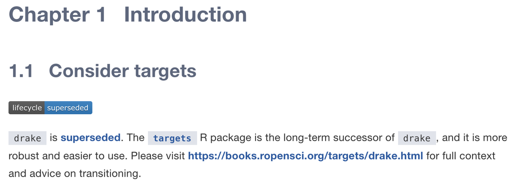

- They really are just leveraging an existing infrastructure

## Enter `make`

## Overview of `make` and `Makefile`

## How does it work?

## Targets and prerequisites

## Quick example

## Recall our previous case:

```bash
data
    |_raw_data.csv
    |_clean_data.csv
scripts
    |_clean_data.R
    |_plot_data.R
results
    |_figure1.png
```

## The `Makefile` would simply be:

```bash
target: prerequisites
  how do I build them?

results/figure1.png: scripts/plot_data.R data/clean_data.csv
  Rscript scripts/plot_data.R

data/clean_data.csv: scripts/clean_data.R data/raw_data.csv
  Rscript scripts/clean_data.R
```

And one command does it all: `make`

## Today’s project

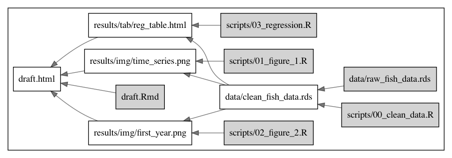

The repo is here: https://github.com/jcvdav/make_tutorial

## Today’s project

Walk you around the repo and set things up

Goals:

- Show you how to `make` your project
- Simulate getting a “fixed” version of the data and re-`make`ing the project
- Simulate getting NEW (or more?) data and re-`make`int the project once again
- Finally, create you own code and add a pair of target / prerequisites
- If we have time, we’ll generalize some of the code (less typing!)

## Other resources

- [Miles McBain “That feeling of workflowing” video lecture](https://youtu.be/jU1Zv21GvT4)
- [There is an `R` in `R`eproducibility](https://towardsdatascience.com/there-is-an-r-in-reproducibility-b9120712742f)
- [Great example from simple to complex with GNU](https://kbroman.org/minimal_make/)
- [GNU Make documentation](https://www.gnu.org/software/make/)